# HW3

Exercise 1

```python
import math
import numpy as np
from matplotlib import pyplot as plt
```

```python
from functools import reduce

def phoretic_velocity(x, y, R, v0, r_c, L):
    """
    Function to calculate the phoretic velocity.

    Parameters
    ==========
    x, y : Positions.
    R : Particle radius.
    v0 : Phoretic reference velocity.
    r_c : Cut-off radius.
    L : Dimension of the squared arena.
    """

    N = np.size(x)

    vx = np.zeros(N)  # Phoretic velocity (x component).
    vy = np.zeros(N)  # Phoretic velocity (y component).

    # Preselect what particles are closer than r_c to the boundaries.
    replicas_needed = reduce(
        np.union1d, (
            np.where(y + r_c > L / 2)[0],
            np.where(y - r_c < - L / 2)[0],
            np.where(x + r_c > L / 2)[0],
            np.where(x - r_c > - L / 2)[0]
        )
    )

    for j in range(N - 1):

        # Check if replicas are needed to find the interacting neighbours.
        if np.size(np.where(replicas_needed == j)[0]):
            # Use replicas.
            xr, yr = replicas(x[j], y[j], L)
            for nr in range(9):
                dist2 = (x[j + 1:] - xr[nr]) ** 2 + (y[j + 1:] - yr[nr]) ** 2
                nn = np.where(dist2 <= r_c ** 2)[0] + j + 1

                # The list of nearest neighbours is set.
                # Contains only the particles with index > j

                if np.size(nn) > 0:
                    nn = nn.astype(int)

                    # Find interaction
                    dx = x[nn] - xr[nr]
                    dy = y[nn] - yr[nr]
                    dist = np.sqrt(dx ** 2 + dy ** 2)
                    v_p = v0 * R ** 2 / dist ** 2
                    dvx = dx / dist * v_p
                    dvy = dy / dist * v_p

                    # Contribution for particle j.
                    vx[j] += np.sum(dvx)
                    vy[j] += np.sum(dvy)

                    # Contribution for nn of particle j nr replica.
                    vx[nn] -= dvx
                    vy[nn] -= dvy

        else:
            dist2 = (x[j + 1:] - x[j]) ** 2 + (y[j + 1:] - y[j]) ** 2
            nn = np.where(dist2 <= r_c ** 2)[0] + j + 1

            # The list of nearest neighbours is set.
            # Contains only the particles with index > j

            if np.size(nn) > 0:
                nn = nn.astype(int)

                # Find interaction
                dx = x[nn] - x[j]
                dy = y[nn] - y[j]
                dist = np.sqrt(dx ** 2 + dy ** 2)
                v_p = v0 * R ** 2 / dist ** 2
                dvx = dx / dist * v_p
                dvy = dy / dist * v_p

                # Contribution for particle j.
                vx[j] += np.sum(dvx)
                vy[j] += np.sum(dvy)

                # Contribution for nn of particle j.
                vx[nn] -= dvx
                vy[nn] -= dvy

    return vx, vy


def replicas(x, y, L):
    """
    Function to generate replicas of a single particle.

    Parameters
    ==========
    x, y : Position.
    L : Side of the squared arena.
    """
    xr = np.zeros(9)
    yr = np.zeros(9)

    for i in range(3):
        for j in range(3):
            xr[3 * i + j] = x + (j - 1) * L
            yr[3 * i + j] = y + (i - 1) * L

    return xr, yr


def pbc(x, y, L):
    """
    Function to enforce periodic boundary conditions on the positions.

    Parameters
    ==========
    x, y : Position.
    L : Side of the squared arena.
    """

    outside_left = np.where(x < - L / 2)[0]
    x[outside_left] = x[outside_left] + L

    outside_right = np.where(x > L / 2)[0]
    x[outside_right] = x[outside_right] - L

    outside_up = np.where(y > L / 2)[0]
    y[outside_up] = y[outside_up] - L

    outside_down = np.where(y < - L / 2)[0]
    y[outside_down] = y[outside_down] + L

    return x, y


def remove_overlap(x, y, R, L, dl, N_max_iter):
    """
    Function to remove the overlap between particles.
    Use the volume exclusion methods.
    If N_max_iter iterations are reached, then it stops.

    Parameters
    ==========
    x, y : Positions.
    R : Particle radius.
    L : Dimension of the squared arena.
    dl : Tolerance on the overlap. Must be much smaller than R.
    N_max_iter : stops if the number of iterations is larger than this.
    """

    N_part = np.size(x)
    step = 0
    running = True

    while running:

        n_overlaps = 0

        for i in np.arange(N_part):
            for j in np.arange(i + 1, N_part):
                # Check overlap.
                dx = x[j] - x[i]
                dy = y[j] - y[i]
                dist = np.sqrt(dx ** 2 + dy ** 2)

                if dist < 2 * R - dl:
                    n_overlaps += 1  # Increment overlap counter.
                    # Remove overlap.
                    xm = 0.5 * (x[j] + x[i])
                    ym = 0.5 * (y[j] + y[i])
                    x[i] = xm - dx / dist * R
                    y[i] = ym - dy / dist * R
                    x[j] = xm + dx / dist * R
                    y[j] = ym + dy / dist * R

        step += 1

        if (step >= N_max_iter) or (n_overlaps == 0):
            running = False

    x, y = pbc(x, y, L)  # Apply periodic boundary conditions.

    return x, y
```

```
The maximum distance possible to travel in a time step with dt = 0.04 is d_max = 8e-07.
Compare this with the radius R = 1e-06. The ratio d_max/R = 0.8 i.e. the particles' centers cent get closer to eachother than 0.2R.
```

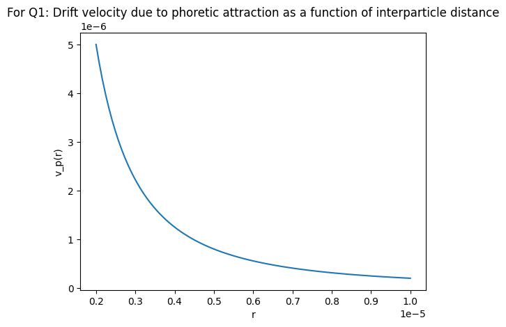

```python
N_part = 200  # Number of active Brownian particles.

R = 1e-6  # Radius of the Brownian particle [m].
eta = 1e-3  # Viscosity of the medium.
gamma = 6 * np.pi * R * eta  # Drag coefficient.
gammaR = 8 * np.pi * R ** 3 * eta  # Rotational drag coefficient.
kBT = 4.11e-21  # kB*T at room temperature [J].
D = kBT / gamma  # Diffusion constant [m^2 / s].
DR = kBT / gammaR  # Rotational diffusion constant [1 / s].
t_r = 1 / DR  # Orientation relaxation time.
dt = 4e-2  # Time step [s].

v = 5e-6  # Self-propulsion speed [m/s].

v0 = 20e-6  # Phoretic reference speed [m/s].
r_c = 10 * R  # Cut-off radius [m].

L = 100 * R  # Side of the arena.

#print(f't_r={t_r:.3f} s')

# Initialization.

# Random position.
x = (np.random.rand(N_part) - 0.5) * L  # in [-L/2, L/2]
y = (np.random.rand(N_part) - 0.5) * L  # in [-L/2, L/2]

# Random orientation.
phi = 2 * (np.random.rand(N_part) - 0.5) * np.pi  # in [-pi, pi]

# Coefficients for the finite difference solution.
c_noise_x = np.sqrt(2 * D * dt)
c_noise_y = np.sqrt(2 * D * dt)
c_noise_phi = np.sqrt(2 * DR * dt)

# Set vp = 0 from the start
vp_x = 0
vp_y = 0

# For plots
t_to_plot = [0, 5, 10, 20, 50]
N_max_steps = t_to_plot[-1]/dt


# For Q1
max_dist_per_step = (2*v+v0*(1/2))*dt
print(f'The maximum distance possible to travel in a time step with dt = {dt} is d_max = {max_dist_per_step:.4}.')
print(f'Compare this with the radius R = {R}. The ratio d_max/R = {max_dist_per_step/R:.4} i.e. the particles\' centers cent get closer to eachother than {(1-max_dist_per_step/R):.4}R.')

r_space = np.linspace(2*R, r_c, 100)
plt.plot(r_space, v0*(R**2/r_space**2))
plt.ylabel('v_p(r)')
plt.xlabel('r')
plt.title('For Q1: Drift velocity due to phoretic attraction as a function of interparticle distance')
```

Q1: We want the distance traveled every time step to be smaller than the radius R to not mess with the volume exclusion method. The maximum distance possible to travel in a time step happens when the speed is as high as possible. This happens when two particles are as close to eachother as possible (2R), making the speed $v_0\frac{R^2}{(2R)^2}= v_0\frac{1}{4}$. If the direction of the self propelling velocity v is also in the direciton of the other particle the speed of the particle is $v+v_0\frac{1}{4}$ in the direction of the other particle. If we now consider that both particles moves with this speed towards eachother they reduce their distance with $(2v+v_0\frac{1}{2})\Delta t$ every time step. So we want $(2v+v_0\frac{1}{2})\Delta t < R$. Otherwise one particle's centre clould pass the other's in one time step, making the volume exclusion method switch the particles positions (they pass through eachother).

As seen in the prints from the cell above, with $\Delta t = 0.04$ the maximum distance the particles can move towards eachother is 0.8R making it so that the particles centers can never pass. One could use a smaller $\Delta t$ but the important part is that the maximum distance should be smaller than R so considering the computational cost of the simulation $\Delta t = 0.04$ is sufficient.

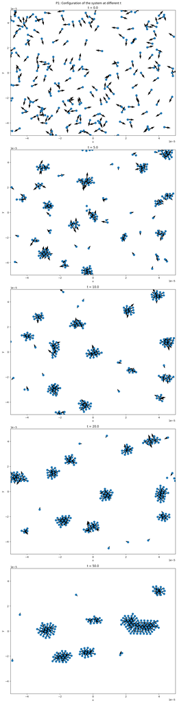

```python
import time
from scipy.constants import Boltzmann as kB
from tkinter import *

visuals_on = False

window_size = 600

vp = 2 * R  # Length of the arrow indicating the velocity direction.
line_width = 1  # Width of the arrow line.

N_skip = 1

fig, ax = plt.subplots(nrows=5, ncols=1, figsize=(10, 40), layout='constrained')
i_fig = 0

if visuals_on:
    tk = Tk()
    tk.geometry(f'{window_size + 20}x{window_size + 20}')
    tk.configure(background='#000000')

    canvas = Canvas(tk, background='#ECECEC')  # Generate animation window
    tk.attributes('-topmost', 0)
    canvas.place(x=10, y=10, height=window_size, width=window_size)

    particles = []
    for j in range(N_part):
        particles.append(
            canvas.create_oval(
                (x[j] - R) / L * window_size + window_size / 2,
                (y[j] - R) / L * window_size + window_size / 2,
                (x[j] + R) / L * window_size + window_size / 2,
                (y[j] + R) / L * window_size + window_size / 2,
                outline='#808080',
                fill='#808080',
            )
        )

    velocities = []
    for j in range(N_part):
        velocities.append(
            canvas.create_line(
                x[j] / L * window_size + window_size / 2,
                y[j] / L * window_size + window_size / 2,
                (x[j] + vp * np.cos(phi[j])) / L * window_size + window_size / 2,
                (y[j] + vp * np.cos(phi[j])) / L * window_size + window_size / 2,
                width=line_width
            )
        )

step = 0

def stop_loop(event):
    global running
    running = False
if visuals_on:
    tk.bind("<Escape>", stop_loop)  # Bind the Escape key to stop the loop.
running = True  # Flag to control the loop.
while running:

    # Check whether plot configuration.
    if step*dt in t_to_plot:
        #ax.clear()  # Clear previous plot.
        ax[i_fig].plot(x, y, '.', markersize=16)
        ax[i_fig].quiver(x, y, v*np.cos(phi)+vp_x, v*np.sin(phi)+vp_y)
        '''ax[i_fig].plot(Rf * np.cos(2 * np.pi * np.arange(360) / 360),
                Rf * np.sin(2 * np.pi * np.arange(360) / 360),
                '-', color='#FFA0FF', linewidth=3)'''
        ax[i_fig].set_xlim([-L / 2, L / 2])
        ax[i_fig].set_ylim([-L / 2, L / 2])
        ax[i_fig].set_title(f't = {step*dt}')
        ax[i_fig].set_xlabel('x')
        ax[i_fig].set_ylabel('y')
        #display(fig)  # Display updated plot.
        #clear_output(wait=True)  # Clear previous output.
        i_fig += 1

    # Calculate phoretic velocity.
    vp_x, vp_y = phoretic_velocity(x, y, R, v0, r_c, L)

    # Calculate new positions and orientations.
    nx = x + (v * np.cos(phi) + vp_x) * dt + c_noise_x * np.random.normal(0, 1, N_part)
    ny = y + (v * np.sin(phi) + vp_y) * dt + c_noise_y * np.random.normal(0, 1, N_part)
    nphi = phi + c_noise_phi * np.random.normal(0, 1, N_part)

    # Apply pbc.
    nx, ny = pbc(nx, ny, L)

    # Remove overlap.
    nx, ny = remove_overlap(nx, ny, R, L, dl=1e-8, N_max_iter=20)

    # Reflecting boundary conditions.
    nx, ny = pbc(nx, ny, L)

    if visuals_on:
        # Update animation frame.
        if step % N_skip == 0:
            for j, particle in enumerate(particles):
                canvas.coords(
                    particle,
                    (nx[j] - R) / L * window_size + window_size / 2,
                    (ny[j] - R) / L * window_size + window_size / 2,
                    (nx[j] + R) / L * window_size + window_size / 2,
                    (ny[j] + R) / L * window_size + window_size / 2,
                )

            for j, velocity in enumerate(velocities):
                canvas.coords(
                    velocity,
                    nx[j] / L * window_size + window_size / 2,
                    ny[j] / L * window_size + window_size / 2,
                    (nx[j] + vp * np.cos(nphi[j])) / L * window_size + window_size / 2,
                    (ny[j] + vp * np.sin(nphi[j])) / L * window_size + window_size / 2,
                )

            tk.title(f'Time {step * dt:.1f} - Iteration {step}')
            tk.update_idletasks()
            tk.update()
            time.sleep(.001)  # Increase to slow down the simulation.







    step += 1
    x[:] = nx[:]
    y[:] = ny[:]
    phi[:] = nphi[:]
    if step == N_max_steps+1:
        running = False
if visuals_on:
    tk.update_idletasks()
    tk.update()
    tk.mainloop()  # Release animation handle (close window to finish).

fig.suptitle('P1: Configuration of the system at different t')
```

Q2: At t = 0 the particles are scattred randomly with random directions. As time increases several clusters (or crystals) are formed and fewer and fewer particles are alone until almost every particle is in one of the fewer and fewer clusters. The direction of travel for the clustering particles are towards the cluster.

```python
# Change L to 50R
N_part = 200  # Number of active Brownian particles.

R = 1e-6  # Radius of the Brownian particle [m].
eta = 1e-3  # Viscosity of the medium.
gamma = 6 * np.pi * R * eta  # Drag coefficient.
gammaR = 8 * np.pi * R ** 3 * eta  # Rotational drag coefficient.
kBT = 4.11e-21  # kB*T at room temperature [J].
D = kBT / gamma  # Diffusion constant [m^2 / s].
DR = kBT / gammaR  # Rotational diffusion constant [1 / s].
t_r = 1 / DR  # Orientation relaxation time.
dt = 4e-2  # Time step [s].

v = 5e-6  # Self-propulsion speed [m/s].

v0 = 20e-6  # Phoretic reference speed [m/s].
r_c = 10 * R  # Cut-off radius [m].

L = 50 * R  # Side of the arena.

print(f't_r={t_r:.3f} s')

# Initialization.

# Random position.
x = (np.random.rand(N_part) - 0.5) * L  # in [-L/2, L/2]
y = (np.random.rand(N_part) - 0.5) * L  # in [-L/2, L/2]

x, y = remove_overlap(x, y, R, L, dl=1e-8, N_max_iter=20)

# Random orientation.
phi = 2 * (np.random.rand(N_part) - 0.5) * np.pi  # in [-pi, pi]

# Coefficients for the finite difference solution.
c_noise_x = np.sqrt(2 * D * dt)
c_noise_y = np.sqrt(2 * D * dt)
c_noise_phi = np.sqrt(2 * DR * dt)

# Set vp = 0 from the start
vp_x = 0
vp_y = 0
```

```
t_r=6.115 s
```

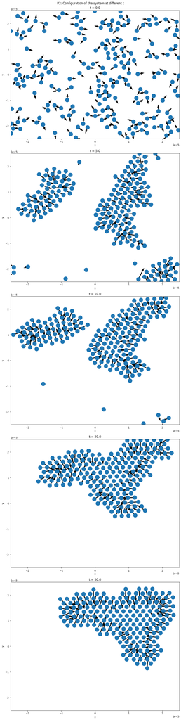

```python
visuals_on = False

window_size = 600

vp = 2 * R  # Length of the arrow indicating the velocity direction.
line_width = 1  # Width of the arrow line.

N_skip = 1

fig, ax = plt.subplots(nrows=5, ncols=1, figsize=(10, 40), layout='constrained')
i_fig = 0

if visuals_on:
    tk = Tk()
    tk.geometry(f'{window_size + 20}x{window_size + 20}')
    tk.configure(background='#000000')

    canvas = Canvas(tk, background='#ECECEC')  # Generate animation window
    tk.attributes('-topmost', 0)
    canvas.place(x=10, y=10, height=window_size, width=window_size)

    particles = []
    for j in range(N_part):
        particles.append(
            canvas.create_oval(
                (x[j] - R) / L * window_size + window_size / 2,
                (y[j] - R) / L * window_size + window_size / 2,
                (x[j] + R) / L * window_size + window_size / 2,
                (y[j] + R) / L * window_size + window_size / 2,
                outline='#808080',
                fill='#808080',
            )
        )

    velocities = []
    for j in range(N_part):
        velocities.append(
            canvas.create_line(
                x[j] / L * window_size + window_size / 2,
                y[j] / L * window_size + window_size / 2,
                (x[j] + vp * np.cos(phi[j])) / L * window_size + window_size / 2,
                (y[j] + vp * np.cos(phi[j])) / L * window_size + window_size / 2,
                width=line_width
            )
        )

step = 0

def stop_loop(event):
    global running
    running = False
if visuals_on:
    tk.bind("<Escape>", stop_loop)  # Bind the Escape key to stop the loop.
running = True  # Flag to control the loop.
while running:

    # Check whether plot configuration.
    if step*dt in t_to_plot:
        #ax.clear()  # Clear previous plot.
        ax[i_fig].plot(x, y, '.', markersize=32)
        ax[i_fig].quiver(x, y, v*np.cos(phi)+vp_x, v*np.sin(phi)+vp_y)
        '''ax[i_fig].plot(Rf * np.cos(2 * np.pi * np.arange(360) / 360),
                Rf * np.sin(2 * np.pi * np.arange(360) / 360),
                '-', color='#FFA0FF', linewidth=3)'''
        ax[i_fig].set_xlim([-L / 2, L / 2])
        ax[i_fig].set_ylim([-L / 2, L / 2])
        ax[i_fig].set_title(f't = {step*dt}')
        ax[i_fig].set_xlabel('x')
        ax[i_fig].set_ylabel('y')
        #display(fig)  # Display updated plot.
        #clear_output(wait=True)  # Clear previous output.
        i_fig += 1

    # Calculate phoretic velocity.
    vp_x, vp_y = phoretic_velocity(x, y, R, v0, r_c, L)

    # Calculate new positions and orientations.
    nx = x + (v * np.cos(phi) + vp_x) * dt + c_noise_x * np.random.normal(0, 1, N_part)
    ny = y + (v * np.sin(phi) + vp_y) * dt + c_noise_y * np.random.normal(0, 1, N_part)
    nphi = phi + c_noise_phi * np.random.normal(0, 1, N_part)

    # Apply pbc.
    nx, ny = pbc(nx, ny, L)

    # Remove overlap.
    nx, ny = remove_overlap(nx, ny, R, L, dl=1e-8, N_max_iter=20)

    # Reflecting boundary conditions.
    nx, ny = pbc(nx, ny, L)

    if visuals_on:
        # Update animation frame.
        if step % N_skip == 0:
            for j, particle in enumerate(particles):
                canvas.coords(
                    particle,
                    (nx[j] - R) / L * window_size + window_size / 2,
                    (ny[j] - R) / L * window_size + window_size / 2,
                    (nx[j] + R) / L * window_size + window_size / 2,
                    (ny[j] + R) / L * window_size + window_size / 2,
                )

            for j, velocity in enumerate(velocities):
                canvas.coords(
                    velocity,
                    nx[j] / L * window_size + window_size / 2,
                    ny[j] / L * window_size + window_size / 2,
                    (nx[j] + vp * np.cos(nphi[j])) / L * window_size + window_size / 2,
                    (ny[j] + vp * np.sin(nphi[j])) / L * window_size + window_size / 2,
                )

            tk.title(f'Time {step * dt:.1f} - Iteration {step}')
            tk.update_idletasks()
            tk.update()
            time.sleep(.001)  # Increase to slow down the simulation.







    step += 1
    x[:] = nx[:]
    y[:] = ny[:]
    phi[:] = nphi[:]
    if step == N_max_steps+1:
        running = False
if visuals_on:
    tk.update_idletasks()
    tk.update()
    tk.mainloop()  # Release animation handle (close window to finish).

fig.suptitle('P2: Configuration of the system at different t')
```

Q3: At t = 0 the particles are scattred randomly with random directions as in P1 with the differance that the particles are more densly packed. As time increases several clusters (or crystals) are formed and fewer and fewer particles are alone until almost every particle is in a singe big cluster. The direction of travel for the clustering particles are towards the cluster. In this plot it is also easier to see that the drift from the phoretic force is small for particles in the center of clusters because the forces cancel from different directions. The main differance between P1 and P2 are that bigger clusters form earlier in P2.

Exercise 2

```python
from functools import reduce

def calculate_intensity(x, y, I0, r0, L, r_c):
    """
    Function to calculate the intensity seen by each particle.

    Parameters
    ==========
    x, y : Positions.
    r0 : Standard deviation of the Gaussian light intensity zone.
    I0 : Maximum intensity of the Gaussian.
    L : Dimension of the squared arena.
    r_c : Cut-off radius. Pre-set it around 3 * r0.
    """

    N = np.size(x)

    I_particle = np.zeros(N)  # Intensity seen by each particle.

    # Preselect what particles are closer than r_c to the boundaries.
    replicas_needed = reduce(
        np.union1d, (
            np.where(y + r_c > L / 2)[0],
            np.where(y - r_c < - L / 2)[0],
            np.where(x + r_c > L / 2)[0],
            np.where(x - r_c > - L / 2)[0]
        )
    )

    for j in range(N - 1):

        # Check if replicas are needed to find the interacting neighbours.
        if np.size(np.where(replicas_needed == j)[0]):
            # Use replicas.
            xr, yr = replicas(x[j], y[j], L)
            for nr in range(9):
                dist2 = (x[j + 1:] - xr[nr]) ** 2 + (y[j + 1:] - yr[nr]) ** 2
                nn = np.where(dist2 <= r_c ** 2)[0] + j + 1

                # The list of nearest neighbours is set.
                # Contains only the particles with index > j

                if np.size(nn) > 0:
                    nn = nn.astype(int)

                    # Find total intensity
                    dx = x[nn] - xr[nr]
                    dy = y[nn] - yr[nr]
                    d2 = dx ** 2 + dy ** 2
                    I = I0 * np.exp(- d2 / r0 ** 2)

                    # Contribution for particle j.
                    I_particle[j] += np.sum(I)

                    # Contribution for nn of particle j nr replica.
                    I_particle[nn] += I

        else:
            dist2 = (x[j + 1:] - x[j]) ** 2 + (y[j + 1:] - y[j]) ** 2
            nn = np.where(dist2 <= r_c ** 2)[0] + j + 1

            # The list of nearest neighbours is set.
            # Contains only the particles with index > j

            if np.size(nn) > 0:
                nn = nn.astype(int)

                # Find interaction
                dx = x[nn] - x[j]
                dy = y[nn] - y[j]
                d2 = dx ** 2 + dy ** 2
                I = I0 * np.exp(- d2 / r0 ** 2)

                # Contribution for particle j.
                I_particle[j] += np.sum(I)

                # Contribution for nn of particle j.
                I_particle[nn] += I

    return I_particle
```

```python
N_part = 50  # Number of light-sensitive robots.
# Note: 5 is enough to demonstrate clustering - dispersal.

tau = 1  # Timescale of the orientation diffusion.
dt = 0.05  # Time step [s].

v0 = 0.1  # Self-propulsion speed at I=0 [m/s].
v_inf = 0.01  # Self-propulsion speed at I=+infty [m/s].
Ic = 0.1  # Intensity scale where the speed decays.
I0 = 1  # Maximum intensity.
r0 = 0.3  # Standard deviation of the Gaussian light intensity zone [m].

# delta = 0  # No delay. Tends to cluster.
delta = 5 * tau  # Positive delay. More stable clustering.
# delta = - 5 * tau  # Negative delay. Dispersal.

r_c = 4 * r0  # Cut-off radius [m].
L = 50 * r0  # Side of the arena[m].

# Initialization.

# Random position.
x = (np.random.rand(N_part) - 0.5) * L  # in [-L/2, L/2]
y = (np.random.rand(N_part) - 0.5) * L  # in [-L/2, L/2]

# Random orientation.
phi = 2 * (np.random.rand(N_part) - 0.5) * np.pi  # in [-pi, pi]

# Coefficients for the finite difference solution.
c_noise_phi = np.sqrt(2 * dt / tau)

n_fit = 5
if delta < 0:
    # Negative delay.
    n_fit = 5
    I_fit = np.zeros([n_fit, N_part])
    t_fit = np.arange(n_fit) * dt
    dI_dt = np.zeros(N_part)
    # Initialize.
    I_ref = I0 * np.exp(- (x ** 2 + y ** 2) / r0 ** 2)
    for i in range(n_fit):
        I_fit[i, :] += I_ref

if delta > 0:
    # Positive delay.
    n_delay = int(delta / dt)  # Delay in units of time steps.
    I_memory = np.zeros([n_delay, N_part])
    # Initialize.
    I_ref = I0 * np.exp(- (x ** 2 + y ** 2) / r0 ** 2)
    for i in range(n_fit):
        I_memory[i, :] += I_ref



# For plots
t_to_plot = [0, 10, 100, 500, 1000]
N_max_steps = t_to_plot[-1]/dt
```

```
0.0
10.0
100.0
500.0
1000.0
```

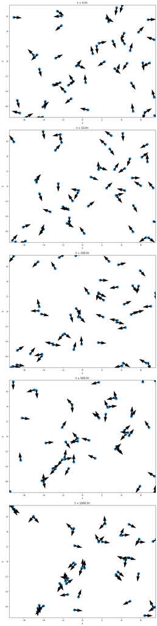

```python
import time
from scipy.constants import Boltzmann as kB
from tkinter import *

visuals_on = False

fig, ax = plt.subplots(nrows=5, ncols=1, figsize=(10, 40), layout='constrained')
i_fig = 0
points_whole_ax = 5 * 0.8 * 72    # 1 point = dpi / 72 pixels
points_radius = 2 * r0 / L * points_whole_ax

window_size = 600

rp = r0 / 3
vp = rp  # Length of the arrow indicating the velocity direction.
line_width = 1  # Width of the arrow line.

N_skip = 2

if visuals_on:
    tk = Tk()
    tk.geometry(f'{window_size + 20}x{window_size + 20}')
    tk.configure(background='#000000')

    canvas = Canvas(tk, background='#ECECEC')  # Generate animation window
    tk.attributes('-topmost', 0)
    canvas.place(x=10, y=10, height=window_size, width=window_size)

    light_spots = []
    for j in range(N_part):
        light_spots.append(
            canvas.create_oval(
                (x[j] - r0) / L * window_size + window_size / 2,
                (y[j] - r0) / L * window_size + window_size / 2,
                (x[j] + r0) / L * window_size + window_size / 2,
                (y[j] + r0) / L * window_size + window_size / 2,
                outline='#FF8080',
            )
        )

    particles = []
    for j in range(N_part):
        particles.append(
            canvas.create_oval(
                (x[j] - rp) / L * window_size + window_size / 2,
                (y[j] - rp) / L * window_size + window_size / 2,
                (x[j] + rp) / L * window_size + window_size / 2,
                (y[j] + rp) / L * window_size + window_size / 2,
                outline='#000000',
                fill='#A0A0A0',
            )
        )

    velocities = []
    for j in range(N_part):
        velocities.append(
            canvas.create_line(
                x[j] / L * window_size + window_size / 2,
                y[j] / L * window_size + window_size / 2,
                (x[j] + vp * np.cos(phi[j])) / L * window_size + window_size / 2,
                (y[j] + vp * np.cos(phi[j])) / L * window_size + window_size / 2,
                width=line_width,
            )
        )

step = 0

def stop_loop(event):
    global running
    running = False

if visuals_on:
    tk.bind("<Escape>", stop_loop)  # Bind the Escape key to stop the loop.
running = True  # Flag to control the loop.
while running:

    # Check whether plot configuration.
    if step*dt in t_to_plot:
        print(step*dt)
        if step*dt == 100:
            x1_100 = x
            y1_100 = y
        if step*dt == 500:
            x1_500 = x
            y1_500 = y
        #ax.clear()  # Clear previous plot.
        ax[i_fig].scatter(x, y, s=points_radius**2)
        ax[i_fig].quiver(x, y, np.cos(phi), np.sin(phi))
        '''ax[i_fig].plot(Rf * np.cos(2 * np.pi * np.arange(360) / 360),
                Rf * np.sin(2 * np.pi * np.arange(360) / 360),
                '-', color='#FFA0FF', linewidth=3)'''
        ax[i_fig].set_xlim([-L / 2, L / 2])
        ax[i_fig].set_ylim([-L / 2, L / 2])
        ax[i_fig].set_title(f't = {step*dt}τ')
        ax[i_fig].set_xlabel('x')
        ax[i_fig].set_ylabel('y')
        #display(fig)  # Display updated plot.
        #clear_output(wait=True)  # Clear previous output.
        i_fig += 1

    # Calculate current I.
    I_particles = calculate_intensity(x, y, I0, r0, L, r_c)

    if delta < 0:
        # Estimate the derivative of I linear using the last n_fit values.
        for i in range(N_part - 1):
            # Update I_fit.
            I_fit = np.roll(I_fit, -1, axis=0)
            I_fit[-1, :] = I_particles
            # Fit to determine the slope.
            for j in range(N_part):
                p = np.polyfit(t_fit, I_fit[:, j], 1)
                dI_dt[j] = p[0]
            # Determine forecast. Remember that here delta is negative.
            I = I_particles - delta * dI_dt
            I[np.where(I < 0)[0]] = 0
    elif delta > 0:
        # Update I_memory.
        I_memory = np.roll(I_memory, -1, axis=0)
        I_memory[-1, :] = I_particles
        I = I_memory[0, :]
    else:
        I = I_particles

    # Calculate new positions and orientations.
    v = v_inf + (v0 - v_inf) * np.exp(- I / Ic)
    nx = x + v * dt * np.cos(phi)
    ny = y + v * dt * np.sin(phi)
    nphi = phi + c_noise_phi * np.random.normal(0, 1, N_part)


    # Apply pbc.
    nx, ny = pbc(nx, ny, L)

    if visuals_on:
        # Update animation frame.
        if step % N_skip == 0:

            for j, light_spot in enumerate(light_spots):
                canvas.coords(
                    light_spot,
                    (nx[j] - r0) / L * window_size + window_size / 2,
                    (ny[j] - r0) / L * window_size + window_size / 2,
                    (nx[j] + r0) / L * window_size + window_size / 2,
                    (ny[j] + r0) / L * window_size + window_size / 2,
                )

            for j, particle in enumerate(particles):
                canvas.coords(
                    particle,
                    (nx[j] - rp) / L * window_size + window_size / 2,
                    (ny[j] - rp) / L * window_size + window_size / 2,
                    (nx[j] + rp) / L * window_size + window_size / 2,
                    (ny[j] + rp) / L * window_size + window_size / 2,
                )

            for j, velocity in enumerate(velocities):
                canvas.coords(
                    velocity,
                    nx[j] / L * window_size + window_size / 2,
                    ny[j] / L * window_size + window_size / 2,
                    (nx[j] + vp * np.cos(nphi[j])) / L * window_size + window_size / 2,
                    (ny[j] + vp * np.sin(nphi[j])) / L * window_size + window_size / 2,
                )

            tk.title(f'Time {step * dt:.1f} - Iteration {step}')
            tk.update_idletasks()
            tk.update()
            time.sleep(.001)  # Increase to slow down the simulation.

    step += 1
    x[:] = nx[:]
    y[:] = ny[:]
    phi[:] = nphi[:]

    if step == N_max_steps+1:
        running = False

if visuals_on:
    tk.update_idletasks()
    tk.update()
    tk.mainloop()  # Release animation handle (close window to finish).
```

```python
N_part = 50  # Number of light-sensitive robots.
# Note: 5 is enough to demonstrate clustering - dispersal.

tau = 1  # Timescale of the orientation diffusion.
dt = 0.05  # Time step [s].

v0 = 0.1  # Self-propulsion speed at I=0 [m/s].
v_inf = 0.01  # Self-propulsion speed at I=+infty [m/s].
Ic = 0.1  # Intensity scale where the speed decays.
I0 = 1  # Maximum intensity.
r0 = 0.3  # Standard deviation of the Gaussian light intensity zone [m].

# delta = 0  # No delay. Tends to cluster.
# delta = 5 * tau  # Positive delay. More stable clustering.
delta = - 5 * tau  # Negative delay. Dispersal.

r_c = 4 * r0  # Cut-off radius [m].
L = 50 * r0  # Side of the arena[m].

# Initialization.

# Random position.
x = (np.random.rand(N_part) - 0.5) * L  # in [-L/2, L/2]
y = (np.random.rand(N_part) - 0.5) * L  # in [-L/2, L/2]

# Random orientation.
phi = 2 * (np.random.rand(N_part) - 0.5) * np.pi  # in [-pi, pi]

# Coefficients for the finite difference solution.
c_noise_phi = np.sqrt(2 * dt / tau)


if delta < 0:
    # Negative delay.
    n_fit = 5
    I_fit = np.zeros([n_fit, N_part])
    t_fit = np.arange(n_fit) * dt
    dI_dt = np.zeros(N_part)
    # Initialize.
    I_ref = I0 * np.exp(- (x ** 2 + y ** 2) / r0 ** 2)
    for i in range(n_fit):
        I_fit[i, :] += I_ref

if delta > 0:
    # Positive delay.
    n_delay = int(delta / dt)  # Delay in units of time steps.
    I_memory = np.zeros([n_delay, N_part])
    # Initialize.
    I_ref = I0 * np.exp(- (x ** 2 + y ** 2) / r0 ** 2)
    for i in range(n_fit):
        I_memory[i, :] += I_ref



# For plots
t_to_plot = [0, 10, 100, 500]
N_max_steps = t_to_plot[-1]/dt
```

```
0.0
10.0
100.0
500.0
```

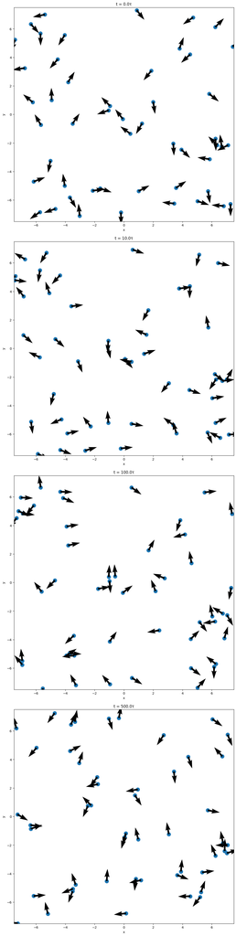

```python
import time
from scipy.constants import Boltzmann as kB
from tkinter import *

visuals_on = False

fig, ax = plt.subplots(nrows=4, ncols=1, figsize=(10, 40), layout='constrained')
i_fig = 0
points_whole_ax = 5 * 0.8 * 72    # 1 point = dpi / 72 pixels
points_radius = 2 * r0 / L * points_whole_ax


window_size = 600

rp = r0 / 3
vp = rp  # Length of the arrow indicating the velocity direction.
line_width = 1  # Width of the arrow line.

N_skip = 2

if visuals_on:
    tk = Tk()
    tk.geometry(f'{window_size + 20}x{window_size + 20}')
    tk.configure(background='#000000')

    canvas = Canvas(tk, background='#ECECEC')  # Generate animation window
    tk.attributes('-topmost', 0)
    canvas.place(x=10, y=10, height=window_size, width=window_size)

    light_spots = []
    for j in range(N_part):
        light_spots.append(
            canvas.create_oval(
                (x[j] - r0) / L * window_size + window_size / 2,
                (y[j] - r0) / L * window_size + window_size / 2,
                (x[j] + r0) / L * window_size + window_size / 2,
                (y[j] + r0) / L * window_size + window_size / 2,
                outline='#FF8080',
            )
        )

    particles = []
    for j in range(N_part):
        particles.append(
            canvas.create_oval(
                (x[j] - rp) / L * window_size + window_size / 2,
                (y[j] - rp) / L * window_size + window_size / 2,
                (x[j] + rp) / L * window_size + window_size / 2,
                (y[j] + rp) / L * window_size + window_size / 2,
                outline='#000000',
                fill='#A0A0A0',
            )
        )

    velocities = []
    for j in range(N_part):
        velocities.append(
            canvas.create_line(
                x[j] / L * window_size + window_size / 2,
                y[j] / L * window_size + window_size / 2,
                (x[j] + vp * np.cos(phi[j])) / L * window_size + window_size / 2,
                (y[j] + vp * np.cos(phi[j])) / L * window_size + window_size / 2,
                width=line_width,
            )
        )

step = 0

def stop_loop(event):
    global running
    running = False

if visuals_on:
    tk.bind("<Escape>", stop_loop)  # Bind the Escape key to stop the loop.
running = True  # Flag to control the loop.
while running:

    # Check whether plot configuration.
    if step*dt in t_to_plot:
        print(step*dt)
        if step*dt == 100:
            x2_100 = x
            y2_100 = y
        if step*dt == 500:
            x2_500 = x
            y2_500 = y
        #ax.clear()  # Clear previous plot.
        ax[i_fig].scatter(x, y, s=points_radius**2)
        ax[i_fig].quiver(x, y, np.cos(phi), np.sin(phi))
        '''ax[i_fig].plot(Rf * np.cos(2 * np.pi * np.arange(360) / 360),
                Rf * np.sin(2 * np.pi * np.arange(360) / 360),
                '-', color='#FFA0FF', linewidth=3)'''
        ax[i_fig].set_xlim([-L / 2, L / 2])
        ax[i_fig].set_ylim([-L / 2, L / 2])
        ax[i_fig].set_title(f't = {step*dt}τ')
        ax[i_fig].set_xlabel('x')
        ax[i_fig].set_ylabel('y')
        #display(fig)  # Display updated plot.
        #clear_output(wait=True)  # Clear previous output.
        i_fig += 1

    # Calculate current I.
    I_particles = calculate_intensity(x, y, I0, r0, L, r_c)

    if delta < 0:
        # Estimate the derivative of I linear using the last n_fit values.
        for i in range(N_part - 1):
            # Update I_fit.
            I_fit = np.roll(I_fit, -1, axis=0)
            I_fit[-1, :] = I_particles
            # Fit to determine the slope.
            for j in range(N_part):
                p = np.polyfit(t_fit, I_fit[:, j], 1)
                dI_dt[j] = p[0]
            # Determine forecast. Remember that here delta is negative.
            I = I_particles - delta * dI_dt
            I[np.where(I < 0)[0]] = 0
    elif delta > 0:
        # Update I_memory.
        I_memory = np.roll(I_memory, -1, axis=0)
        I_memory[-1, :] = I_particles
        I = I_memory[0, :]
    else:
        I = I_particles

    # Calculate new positions and orientations.
    v = v_inf + (v0 - v_inf) * np.exp(- I / Ic)
    nx = x + v * dt * np.cos(phi)
    ny = y + v * dt * np.sin(phi)
    nphi = phi + c_noise_phi * np.random.normal(0, 1, N_part)


    # Apply pbc.
    nx, ny = pbc(nx, ny, L)

    if visuals_on:
        # Update animation frame.
        if step % N_skip == 0:

            for j, light_spot in enumerate(light_spots):
                canvas.coords(
                    light_spot,
                    (nx[j] - r0) / L * window_size + window_size / 2,
                    (ny[j] - r0) / L * window_size + window_size / 2,
                    (nx[j] + r0) / L * window_size + window_size / 2,
                    (ny[j] + r0) / L * window_size + window_size / 2,
                )

            for j, particle in enumerate(particles):
                canvas.coords(
                    particle,
                    (nx[j] - rp) / L * window_size + window_size / 2,
                    (ny[j] - rp) / L * window_size + window_size / 2,
                    (nx[j] + rp) / L * window_size + window_size / 2,
                    (ny[j] + rp) / L * window_size + window_size / 2,
                )

            for j, velocity in enumerate(velocities):
                canvas.coords(
                    velocity,
                    nx[j] / L * window_size + window_size / 2,
                    ny[j] / L * window_size + window_size / 2,
                    (nx[j] + vp * np.cos(nphi[j])) / L * window_size + window_size / 2,
                    (ny[j] + vp * np.sin(nphi[j])) / L * window_size + window_size / 2,
                )

            tk.title(f'Time {step * dt:.1f} - Iteration {step}')
            tk.update_idletasks()
            tk.update()
            time.sleep(.001)  # Increase to slow down the simulation.

    step += 1
    x[:] = nx[:]
    y[:] = ny[:]
    phi[:] = nphi[:]

    if step == N_max_steps+1:
        running = False

if visuals_on:
    tk.update_idletasks()
    tk.update()
    tk.mainloop()  # Release animation handle (close window to finish).
```

```python
from scipy.spatial import distance
import sys
import numpy
numpy.set_printoptions(threshold=sys.maxsize)

# DOESEN'T WORK

# def clusters(x, y):
#     cluster = []
#     coords = np.vstack([x,y]).T
#     to_delete = []
#     print(x.shape)
#     print(coords.shape)
#     distances = distance.cdist(coords, coords, 'euclidean')
#     less_than_r0 = distances<r0
#     n, m = less_than_r0.shape
#     for i in range(n):
#         inds = np.where(less_than_r0[i,:])[0]
#         #print(i)
#         if len(inds) != 1:
#             print(inds, len(inds))
#             cluster.append(inds.tolist())




#             '''for index in inds:
#                 print(f'index {index}')
#                 print(cluster)
#                 print(np.where(cluster==index)[0])
#                 already_ins = np.where(cluster==index)[0]
#                 print(already_ins)
#                 if len(already_ins) > 1:
#                     for already_in in already_ins:
#                         cluster[already_in].append(inds)
#                 else:
#                     cluster.append(inds)'''
#     for i in range(len(cluster)):
#         for j in range(i+1, len(cluster)):
#             if cluster[i] == cluster[j]:
#                 to_delete.append(j)

#     to_delete.sort(reverse=True)
#     for i in to_delete:
#         del cluster[i]
#     print(cluster)



#     return cluster













# cluster = clusters(x1_500, y1_500)
# plt.scatter(x1_500, y1_500)

# for inds in cluster:
#     for index in inds:
#         plt.scatter(x1_500[index], y1_500[index], c='r')
```

```python
def find_clusters(x, y, r0):
    """
    Identifies clusters of particles based on a distance threshold r0.

    Parameters:
        x (np.ndarray): An N x 1 array representing N particles x position.
        y (np.ndarray): An N x 1 array representing N particles y position.
        r0 (float): Distance threshold for clustering.

    Returns:
        list: A list of clusters, where each cluster is a list of particle indices.
    """
    particles = np.vstack([x, y]).T

    # Number of particles
    n_particles = len(particles)

    # Initialize union-find (disjoint-set) data structure
    parent = list(range(n_particles))

    def find(x):
        """Find with path compression."""
        if parent[x] != x:
            parent[x] = find(parent[x])
        return parent[x]

    def union(x, y):
        """Union two sets."""
        root_x = find(x)
        root_y = find(y)
        if root_x != root_y:
            parent[root_y] = root_x

    # Check distances between all pairs of particles
    for i in range(n_particles):
        for j in range(i + 1, n_particles):
            if np.linalg.norm(particles[i] - particles[j]) < r0:
                union(i, j)

    # Group particles into clusters based on their root parent
    clusters = {}
    for i in range(n_particles):
        root = find(i)
        if root not in clusters:
            clusters[root] = []
        clusters[root].append(i)

    clusters = list(clusters.values())

    to_delete = []
    for i in range(len(clusters)):

        if len(clusters[i]) < 2:
            to_delete.append(i)

    to_delete.sort(reverse=True)
    for i in to_delete:
        del clusters[i]


    return clusters

#color_list = ['g', 'r', 'c', 'm', 'y', 'k', 'tab:blue', 'tab:orange', 'tab:purple' , 'tab:brown', 'tab:pink', 'tab:gray', 'tab:olive']
colors = [
    "blue", "orange", "green", "red", "purple", "brown", "pink", "gray", "olive", "cyan",
    "darkblue", "gold", "lime", "crimson", "violet", "teal", "darkred", "silver", "darkgreen", "magenta"
]

r0 = 0.3
L = 50 * r0  # Side of the arena[m].
```

```
Clusters: 14
```

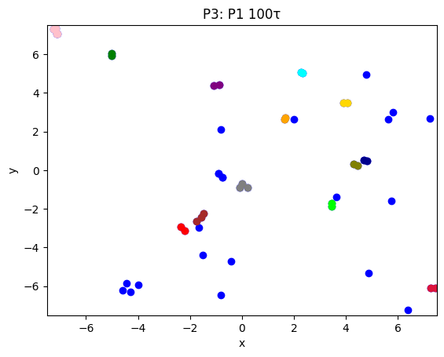

```python
cluster = find_clusters(x1_100, y1_100, r0)
print("Clusters:", len(cluster))

plt.scatter(x1_100, y1_100, c='b')
i = 0
for inds in cluster:

    color = colors[i]
    i += 1
    for index in inds:
        plt.scatter(x1_100[index], y1_100[index], c=color)

plt.xlabel('x')
plt.ylabel('y')
plt.xlim([-L / 2, L / 2])
plt.ylim([-L / 2, L / 2])
plt.title('P3: P1 100τ')
```

```
Clusters: 14
```

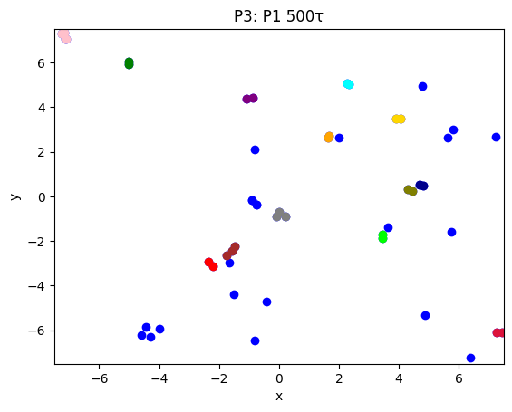

```python
cluster = find_clusters(x1_500, y1_500, r0)
print("Clusters:", len(cluster))

plt.scatter(x1_500, y1_500, c='b')
i = 0
for inds in cluster:

    color = colors[i]
    i += 1
    for index in inds:
        plt.scatter(x1_500[index], y1_500[index], c=color)

plt.xlabel('x')
plt.ylabel('y')
plt.xlim([-L / 2, L / 2])
plt.ylim([-L / 2, L / 2])
plt.title('P3: P1 500τ')
```

```
Clusters: 5
```

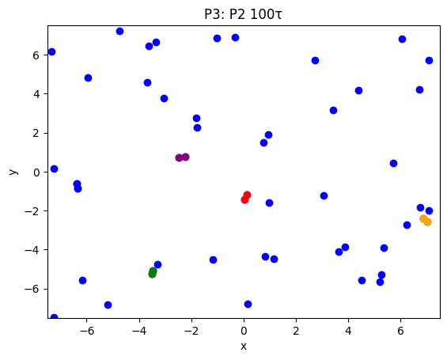

```python
cluster = find_clusters(x2_100, y2_100, r0)
print("Clusters:", len(cluster))

plt.scatter(x2_100, y2_100, c='b')
i = 0
for inds in cluster:

    color = colors[i]
    i += 1
    for index in inds:
        plt.scatter(x2_100[index], y2_100[index], c=color)

plt.xlabel('x')
plt.ylabel('y')
plt.xlim([-L / 2, L / 2])
plt.ylim([-L / 2, L / 2])
plt.title('P3: P2 100τ')
```

```
Clusters: 5
```

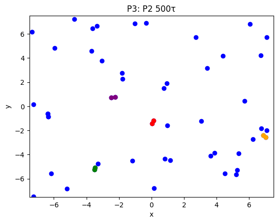

```python
cluster = find_clusters(x2_500, y2_500, r0)
print("Clusters:", len(cluster))

plt.scatter(x2_500, y2_500, c='b')
i = 0
for inds in cluster:

    color = colors[i]
    i += 1
    for index in inds:
        plt.scatter(x2_500[index], y2_500[index], c=color)

plt.xlabel('x')
plt.ylabel('y')
plt.xlim([-L / 2, L / 2])
plt.ylim([-L / 2, L / 2])
plt.title('P3: P2 500τ')
```

Q1: The robots cluster far less in P2 than in P1.